# EDA and Predicting House Pricing from Iowa house prices dataset

```python
import pandas as pd
import seaborn as sns
import matplotlib.pyplot as plt
from sklearn.preprocessing import LabelEncoder
from sklearn.model_selection import GridSearchCV, cross_val_score, train_test_split
from sklearn.metrics import mean_absolute_error
import category_encoders as ce
from  scipy.stats import linregress
import numpy as np
from sklearn.preprocessing import StandardScaler, RobustScaler, FunctionTransformer
```

```python
df = pd.read_csv('C:\\Users\\Renz\\Desktop\\Data Science\\Python stuff\\train.csv', index_col= 'Id')
test = pd.read_csv('C:\\Users\\Renz\\Desktop\\Data Science\\Python stuff\\test.csv', index_col= 'Id')
```

Need to clean up useful columns!

```python
nulls = pd.DataFrame(df.isnull().sum())
nulls.sort_values(by= [0], ascending = False).head(19)##not much missing values! XD
```

|  | 0 |
| --- | --- |
| PoolQC | 1453 |
| MiscFeature | 1406 |
| Alley | 1369 |
| Fence | 1179 |
| FireplaceQu | 690 |
| LotFrontage | 259 |
| GarageYrBlt | 81 |
| GarageCond | 81 |
| GarageType | 81 |
| GarageFinish | 81 |
| GarageQual | 81 |
| BsmtExposure | 38 |
| BsmtFinType2 | 38 |
| BsmtCond | 37 |
| BsmtQual | 37 |
| BsmtFinType1 | 37 |
| MasVnrArea | 8 |
| MasVnrType | 8 |
| Electrical | 1 |

Visualize data to SalePrice to see relationship.

```python
#segregate numerical and categorical columns to easier visualize, among other things
num_cols  = [col for col in df.columns if df[col].dtype != 'object']
obj_cols = [col for col in df.columns if df[col].dtype == 'object']
y = df.SalePrice
ylog = np.log(y)
dfscale = pd.DataFrame(StandardScaler().fit_transform(df[num_cols]), index = df[num_cols].index, columns= num_cols)
yscale = dfscale.SalePrice
num_cols.remove('SalePrice')
yscale
```

```
Id
1       0.347273
2       0.007288
3       0.536154
4      -0.515281
5       0.869843
          ...
1456   -0.074560
1457    0.366161
1458    1.077611
1459   -0.488523
1460   -0.420841
Name: SalePrice, Length: 1460, dtype: float64
```

```python
#concat train and test to visualize MORE  data for features, as visualizing train only might not be representative  of  the whole data.
vf = pd.concat([df.drop('SalePrice', axis  = 1), test],  axis  = 0  )
vf_nulls = pd.DataFrame(vf.isnull().sum(), index = vf.columns)
vf_nulls.sort_values(by = [0], ascending = False).head(35)
```

|  | 0 |
| --- | --- |
| PoolQC | 2909 |
| MiscFeature | 2814 |
| Alley | 2721 |
| Fence | 2348 |
| FireplaceQu | 1420 |
| LotFrontage | 486 |
| GarageYrBlt | 159 |
| GarageFinish | 159 |
| GarageQual | 159 |
| GarageCond | 159 |
| GarageType | 157 |
| BsmtExposure | 82 |
| BsmtCond | 82 |
| BsmtQual | 81 |
| BsmtFinType2 | 80 |
| BsmtFinType1 | 79 |
| MasVnrType | 24 |
| MasVnrArea | 23 |
| MSZoning | 4 |
| Functional | 2 |
| BsmtHalfBath | 2 |
| BsmtFullBath | 2 |
| Utilities | 2 |
| SaleType | 1 |
| BsmtFinSF1 | 1 |
| KitchenQual | 1 |
| GarageCars | 1 |
| BsmtUnfSF | 1 |
| TotalBsmtSF | 1 |
| Exterior2nd | 1 |
| Exterior1st | 1 |
| GarageArea | 1 |
| Electrical | 1 |
| BsmtFinSF2 | 1 |
| TotRmsAbvGrd | 0 |

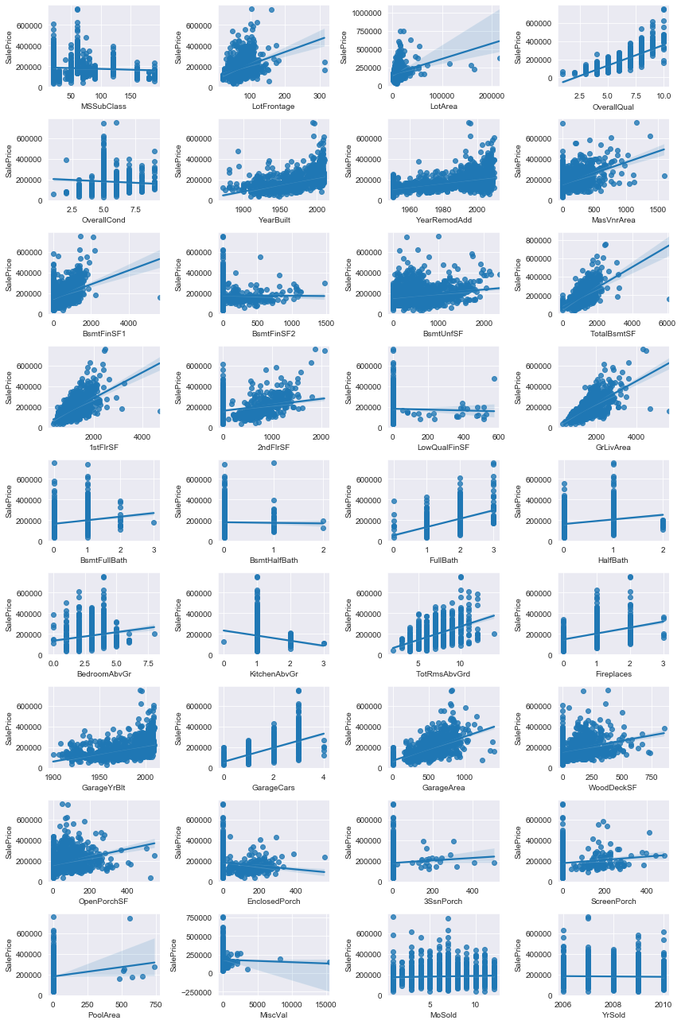

```python
#direct correlation of numerical values to saleprice of test
fig = plt.figure(figsize= (12,18))
for n in num_cols:
    sns.set_style('darkgrid')
    fig.add_subplot(9,4,num_cols.index(n)+1)
    sns.regplot(x= n,   y = 'SalePrice',  data = df)
    plt.xlabel = n
plt.tight_layout()
plt.show()
```

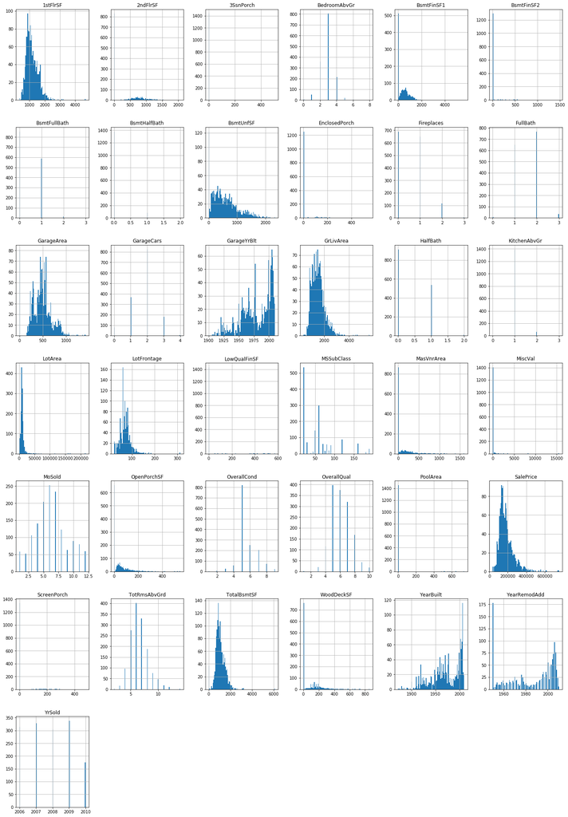

```python
#histogram of num values
df.hist(bins = 100, figsize = (24,36
                              ))
plt.show()
```

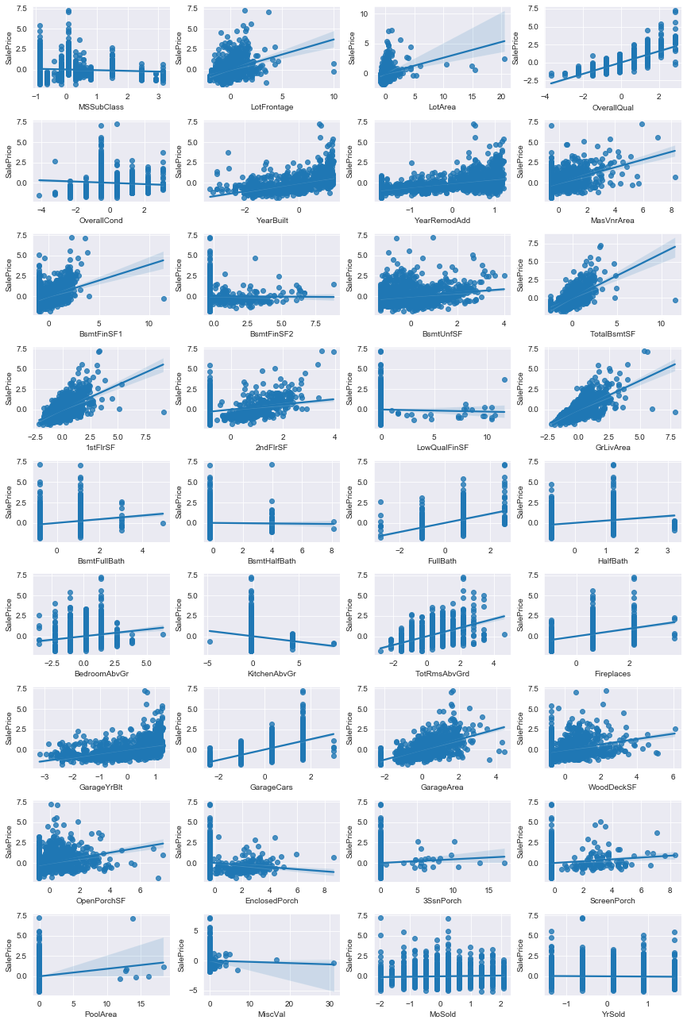

```python
#try standard scaler:
numwithy = df[num_cols].join(y)
dfscale = pd.DataFrame(StandardScaler().fit_transform(numwithy), index = df.index, columns= numwithy.columns)
fig = plt.figure(figsize= (12,18))
for n in num_cols:
    sns.set_style('darkgrid')
    fig.add_subplot(9,4,num_cols.index(n)+1)
    sns.regplot(x= n,   y = 'SalePrice',  data = dfscale)
    plt.xlabel = n
plt.tight_layout()
plt.show()
```

```python
#regline slope from -1 to 1: HAHAHA THIS IS PEARSON CORREL COEFF OR SIMPLY CORR()
LowSlope=[]
for n  in num_cols:
    slope, intercept, r_value, p_value, std_err = linregress(dfscale[n], dfscale['SalePrice'])
    if -0.1 < slope < 0.1:
        LowSlope.append(n)
LowSlope
```

```
['MSSubClass',
 'OverallCond',
 'BsmtFinSF2',
 'LowQualFinSF',
 'BsmtHalfBath',
 '3SsnPorch',
 'PoolArea',
 'MiscVal',
 'MoSold',
 'YrSold']
```

```python
#measuring correlation  with pearson's coeff, the fit of the regline to the points.
correl= (df.select_dtypes(exclude=['object'])).corr()
#correl[['SalePrice']].sort_values(['SalePrice'], ascending = False)
```

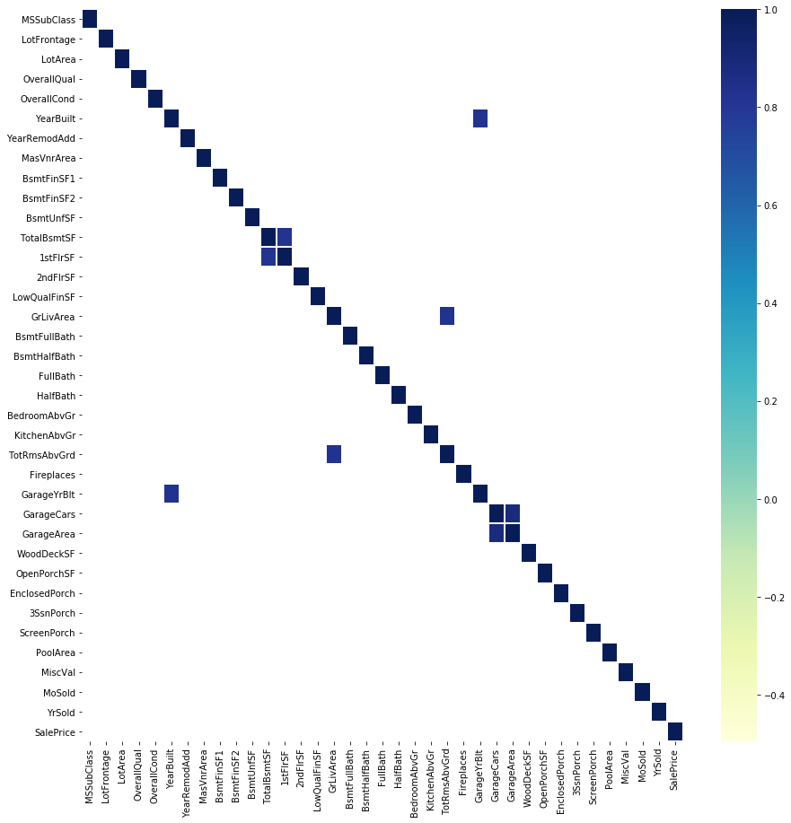

```python
#correlation of  numerical  variables to each other. (some  num var have high correlation with each other, so we  can discard  one  of them as features because they are a good  predictor of each other anyway)
plt.figure(figsize= (15,15))
sns.heatmap(correl, mask= correl <0.8,  cmap="YlGnBu", linewidths = 1)
```

Remove Feature notes NUM FEATURES:

highly correlated features: (drop feature with more missing values)

GarageYrBlt to YearBuilt

TotRmsAbvGrd to GrLivArea

TotalBsmtSF to 1stFlrSF

GarageArea to GarageCars

Too many missing values:

PoolQC 2909

MiscFeature 2814

Alley 2721

Fence 2348

Correlation between -0.1 and 0.1

['MSSubClass', 'OverallCond', 'BsmtFinSF2', 'LowQualFinSF', 'BsmtHalfBath', '3SsnPorch', 'PoolArea', 'MiscVal', 'MoSold', 'YrSold']

To remove: ['GarageYrBlt','TotRmsAbvGrd','TotalBsmtSF','GarageCars', 'PoolQC', 'MiscFeature','Alley','Fence','MSSubClass','OverallCond','BsmtFinSF2','LowQualFinSF','BsmtHalfBath','3SsnPorch','PoolArea','MiscVal','MoSold','YrSold'

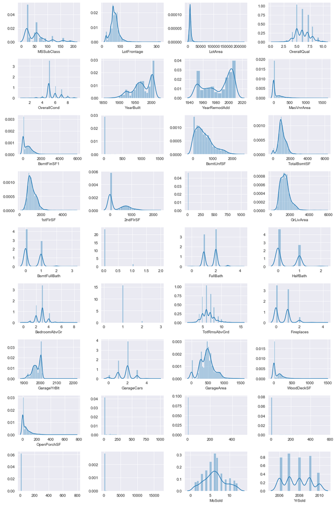

```python
#lets put distplots (histogram) as distrubution and mean is more important in determining features
fig = plt.figure(figsize= (12,18))
skew_dist = []
for n in num_cols:
    sns.set_style('darkgrid')
    fig.add_subplot(9,4,num_cols.index(n)+1)
    try:
        sns.distplot(a= vf[n], kde = True)
    except:
        skew_dist.append(n)
        pass
    plt.xlabel = n
plt.tight_layout()
plt.show()
```

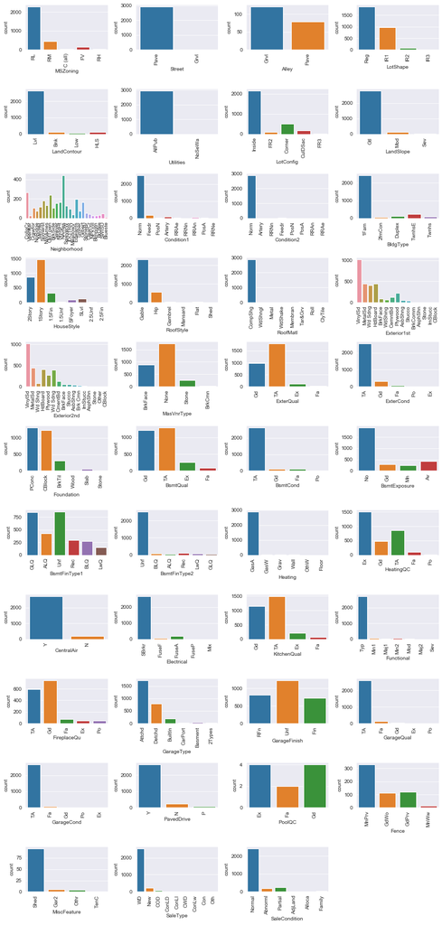

```python
fig = plt.figure(figsize= (12,25))
for n in obj_cols:
    sns.set_style('darkgrid')
    fig.add_subplot(11,4,obj_cols.index(n)+1)
    sns.countplot(x= n, data = vf)
    plt.xlabel = n
    plt.xticks(rotation=90)
plt.tight_layout()
plt.show()
```